# Practical Machine Learning Course Project

fariza

24 December 2015

# Predicting using Weight Lifting Exercise Dataset

### Introduction

The goal of this project is to predict how exercise is performed. This is the “classe” variable in the training set. The performed exercise is classified into five categories: exactly according to the specification (Class A), throwing the elbows to the front (Class B), lifting the dumbbell only halfway (Class C), lowering the dumbbell only halfway (Class D) and throwing the hips to the front (Class E).

### The libraries required

```r
library(caret)
library(randomForest)
library(ggplot2)
library(grid)
library(rpart)
library(rpart.plot)
library(RColorBrewer)
library(rattle)
```

## The Dataset

There are two sets of data; the training data for this project are available here:

https://d396qusza40orc.cloudfront.net/predmachlearn/pml-training.csv

and test data are available here:

https://d396qusza40orc.cloudfront.net/predmachlearn/pml-testing.csv

```r
dataWeightLift = read.csv("C:/Users/user/Documents/R/M8/projectM8/pml-training.csv",header=TRUE)
datatest = read.csv("C:/Users/user/Documents/R/M8/projectM8/pml-testing.csv",header=TRUE)
```

### Understanding the dataset

```r
dim(dataWeightLift)
```

```
## [1] 19622   160
```

```r
str(dataWeightLift, list.len=15)
```

```
## 'data.frame':    19622 obs. of  160 variables:
##  $ X                       : int  1 2 3 4 5 6 7 8 9 10 ...
##  $ user_name               : Factor w/ 6 levels "adelmo","carlitos",..: 2 2 2 2 2 2 2 2 2 2 ...
##  $ raw_timestamp_part_1    : int  1323084231 1323084231 1323084231 1323084232 1323084232 1323084232 1323084232 1323084232 1323084232 1323084232 ...
##  $ raw_timestamp_part_2    : int  788290 808298 820366 120339 196328 304277 368296 440390 484323 484434 ...
##  $ cvtd_timestamp          : Factor w/ 20 levels "02/12/2011 13:32",..: 9 9 9 9 9 9 9 9 9 9 ...
##  $ new_window              : Factor w/ 2 levels "no","yes": 1 1 1 1 1 1 1 1 1 1 ...
##  $ num_window              : int  11 11 11 12 12 12 12 12 12 12 ...
##  $ roll_belt               : num  1.41 1.41 1.42 1.48 1.48 1.45 1.42 1.42 1.43 1.45 ...
##  $ pitch_belt              : num  8.07 8.07 8.07 8.05 8.07 8.06 8.09 8.13 8.16 8.17 ...
##  $ yaw_belt                : num  -94.4 -94.4 -94.4 -94.4 -94.4 -94.4 -94.4 -94.4 -94.4 -94.4 ...
##  $ total_accel_belt        : int  3 3 3 3 3 3 3 3 3 3 ...
##  $ kurtosis_roll_belt      : Factor w/ 397 levels "","-0.016850",..: 1 1 1 1 1 1 1 1 1 1 ...
##  $ kurtosis_picth_belt     : Factor w/ 317 levels "","-0.021887",..: 1 1 1 1 1 1 1 1 1 1 ...
##  $ kurtosis_yaw_belt       : Factor w/ 2 levels "","#DIV/0!": 1 1 1 1 1 1 1 1 1 1 ...
##  $ skewness_roll_belt      : Factor w/ 395 levels "","-0.003095",..: 1 1 1 1 1 1 1 1 1 1 ...
##   [list output truncated]
```

The raw dataset contained 19622 rows of data, with 160 variables. Many variables contained largely missing data (usually with only one row of data), so these need to be removed from the dataset. Also there are data with value that is almost 0 that can be removed.

### Pre procesing the dataset

Since there are many variables that are not complete and contains NA. We also need to reduce the dataset by removing these irrelevant columns. First we remove the first 7 columns in the dataset.

```r
#remove column 1 to  7
#dataWeightLift<-dataWeightLift[c(-1)]
dataWeightLift<-dataWeightLift[, -c(1:7)]
#remove near zero variance data
nzv <- nearZeroVar(dataWeightLift, saveMetrics= TRUE)
nzv[nzv$nzv,][1:10,]
```

```
##                       freqRatio percentUnique zeroVar  nzv
## kurtosis_roll_belt   1921.60000    2.02323922   FALSE TRUE
## kurtosis_picth_belt   600.50000    1.61553358   FALSE TRUE
## kurtosis_yaw_belt      47.33005    0.01019264   FALSE TRUE
## skewness_roll_belt   2135.11111    2.01304658   FALSE TRUE
## skewness_roll_belt.1  600.50000    1.72255631   FALSE TRUE
## skewness_yaw_belt      47.33005    0.01019264   FALSE TRUE
## max_yaw_belt          640.53333    0.34654979   FALSE TRUE
## min_yaw_belt          640.53333    0.34654979   FALSE TRUE
## amplitude_yaw_belt     50.04167    0.02038528   FALSE TRUE
## avg_roll_arm           77.00000    1.68178575   FALSE TRUE
```

```r
myWLdata<-dataWeightLift[,nzv$nzv==FALSE]
dim(myWLdata)
```

```
## [1] 19622    94
```

```r
#remove data with more than 60% NA
myWL <- myWLdata
for(i in 1:length(myWLdata)) {
  if( sum( is.na( myWLdata[, i] ) ) /nrow(myWLdata) >= .7) {
    for(j in 1:length(myWL)) {
      if( length( grep(names(myWLdata[i]), names(myWL)[j]) ) == 1)  {
        myWL <- myWL[ , -j]
      }
    }
  }
}

# Set back to the original variable name
myWLdata <- myWL
rm(myWL)
dim(myWLdata)
```

```
## [1] 19622    53
```

### Cross validation

The trainig dataset is partitioned into two subsets; myTrain and myTest, using 60:40 ratio

```r
#partition into training and test data
inWL<-createDataPartition(myWLdata$classe, p=0.6, list=FALSE)
myTrain<-myWLdata[inWL,]
myTest<-myWLdata[-inWL,]
dim(myTrain)
```

```
## [1] 11776    53
```

```r
dim(myTest)
```

```
## [1] 7846   53
```

## Building Machine Learning Predicting Models : Decision Tree

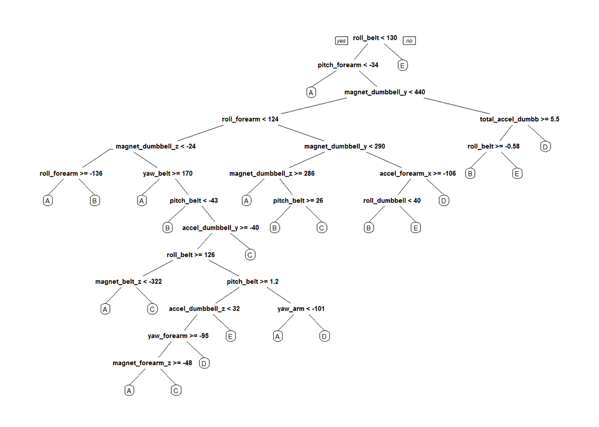

```r
#Train using decision tree rpart
fitr <- rpart(classe~., data=myTrain, method="class")
prp(fitr)
```

```r
set.seed(32343)
FITRpart<-train(classe~., data=myTrain, method="rpart")
predictionsR <- predict(FITRpart, newdata = myTest)
```

```r
confusionMatrix(predictionsR,myTest$classe)
```

```
## Confusion Matrix and Statistics
##
##           Reference
## Prediction    A    B    C    D    E
##          A 2026  646  662  555  215
##          B   35  502   41  218  185
##          C  165  370  665  513  409
##          D    0    0    0    0    0
##          E    6    0    0    0  633
##
## Overall Statistics
##
##                Accuracy : 0.4876
##                  95% CI : (0.4765, 0.4988)
##     No Information Rate : 0.2845
##     P-Value [Acc > NIR] : < 2.2e-16
##
##                   Kappa : 0.3301
##  Mcnemar's Test P-Value : NA
##
## Statistics by Class:
##
##                      Class: A Class: B Class: C Class: D Class: E
## Sensitivity            0.9077  0.33070  0.48611   0.0000  0.43897
## Specificity            0.6299  0.92430  0.77508   1.0000  0.99906
## Pos Pred Value         0.4937  0.51172  0.31338      NaN  0.99061
## Neg Pred Value         0.9449  0.85200  0.87718   0.8361  0.88775
## Prevalence             0.2845  0.19347  0.17436   0.1639  0.18379
## Detection Rate         0.2582  0.06398  0.08476   0.0000  0.08068
## Detection Prevalence   0.5231  0.12503  0.27046   0.0000  0.08144
## Balanced Accuracy      0.7688  0.62750  0.63060   0.5000  0.71902
```

## Building Machine Learning Predicting Models : GBM

```r
set.seed(32343)
modelFit2<-train(classe~., data=myTrain, method="gbm")
#Carryout prediction with gbm model
predictions2<-predict(modelFit2, newdata = myTest)
confusionMatrix(predictions2,myTest$classe)
```

```
## Confusion Matrix and Statistics
##
##           Reference
## Prediction    A    B    C    D    E
##          A 2195   36    0    2    2
##          B   22 1449   64    7   16
##          C    9   33 1287   47   13
##          D    2    0   16 1214   21
##          E    4    0    1   16 1390
##
## Overall Statistics
##
##                Accuracy : 0.9604
##                  95% CI : (0.9558, 0.9646)
##     No Information Rate : 0.2845
##     P-Value [Acc > NIR] : < 2.2e-16
##
##                   Kappa : 0.9499
##  Mcnemar's Test P-Value : 1.688e-11
##
## Statistics by Class:
##
##                      Class: A Class: B Class: C Class: D Class: E
## Sensitivity            0.9834   0.9545   0.9408   0.9440   0.9639
## Specificity            0.9929   0.9828   0.9843   0.9941   0.9967
## Pos Pred Value         0.9821   0.9300   0.9266   0.9689   0.9851
## Neg Pred Value         0.9934   0.9890   0.9875   0.9891   0.9919
## Prevalence             0.2845   0.1935   0.1744   0.1639   0.1838
## Detection Rate         0.2798   0.1847   0.1640   0.1547   0.1772
## Detection Prevalence   0.2849   0.1986   0.1770   0.1597   0.1798
## Balanced Accuracy      0.9881   0.9687   0.9625   0.9690   0.9803
```

Between the two models, gbm produces better accuracy. So prediction on out sample is done on the pml-testing.csv

```r
#to predict with real test data
predictionRF<-predict(FITRpart, newdata = datatest)
```

### Discussion and conclusion

Decision table (Rpart) predicted just 49% accuracy but the gbm or Gradient boosting predicted greater than 95%.

Thus, this model was used to run and predict the test data to be submitted to the coursera assignment submission. You can see that the prediction is as follows, and have been submitted as 20 text files.

```r
predictionGBM<-predict(modelFit2, newdata = datatest)
predictionGBM
```

```
##  [1] B A B A A E D B A A B C B A E E A B B B
## Levels: A B C D E
```